# Difference-in-Differences

From Classical Foundations to Modern Methods

Tyson S. Barrett, PhD

## Today’s Overview

### Part 1: Foundations

- Potential outcomes framework
- Parallel trends assumption
- Classical 2×2 DiD design

### Part 2: When DiD Fails

- Common pitfalls
- TWFE with staggered adoption
- Treatment effect heterogeneity

### Part 3: Solutions

- Heterogeneity-robust methods
- Modern approaches (CS, SA, BJS)

# Part 1: Foundations

## What is Difference-in-Differences?

**Core Idea**

Compare **changes over time** between treated and control groups

**Treatment Group**

- Experiences the intervention
- Δ = After - Before

**Control Group**

- Does not experience intervention
- Δ = After - Before

**Treatment Effect**

**(Treated After - Treated Before) − (Control After - Control Before)**

The “difference-in-differences” removes time-invariant confounding

## Potential Outcomes Framework

**The Fundamental Problem**

We can only observe **one** potential outcome for each unit

### $Y^1_{it}$

Outcome if unit $i$ is **treated** at time $t$

### $Y^0_{it}$

Outcome if unit $i$ is **NOT treated** at time $t$

### Individual Treatment Effect

$$\tau_{it} = Y^1_{it} - Y^0_{it}$$

**The Problem:** We never observe both $Y^1_{it}$ and $Y^0_{it}$ for the same unit at the same time

**DiD’s Solution:** Use control group trends to estimate the missing counterfactual

## The Parallel Trends Assumption

**Core Identifying Assumption**

**Parallel Trends:** In the absence of treatment, the treatment and control groups would have followed parallel outcome trajectories

$$E[Y^0_{i2} - Y^0_{i1} \mid D=1] = E[Y^0_{i2} - Y^0_{i1} \mid D=0]$$

### ✓ What It Allows

- Different baseline levels
- Time-invariant differences
- Common time shocks

### ✗ What It Rules Out

- Differential time trends
- Group-specific shocks
- Pre-existing trend differences

**Note**

This assumption is **untestable** but can be made more plausible through design and diagnostics

## Example 1: Classic 2×2 DiD Design

**Scenario:** State implements minimum wage increase in 2010

```r
# Generate classic 2x2 DiD data
set.seed(123)
data_2x2 <- expand.grid(state = 1:10, year = 2009:2010)

data_2x2 <- data_2x2 %>%
  mutate(
    treat_state = ifelse(state <= 5, 1, 0),
    post = ifelse(year == 2010, 1, 0),
    treated = treat_state * post,
    # True effect = 5
    outcome = 50 + 10*treat_state + 2*post + 5*treated + rnorm(n(), 0, 2)
  )

# Summary statistics
data_2x2 %>%
  group_by(treat_state, post) %>%
  summarise(mean_outcome = mean(outcome), .groups = "drop") %>%
  pivot_wider(names_from = post, values_from = mean_outcome,
              names_prefix = "period_") %>%
  mutate(delta = period_1 - period_0) %>%
  kable(digits = 2, col.names = c("Group", "Pre", "Post", "Δ"))
```

| Group | Pre | Post | Δ |
| --- | --- | --- | --- |
| 0 | 49.91 | 52.22 | 2.31 |
| 1 | 60.39 | 67.62 | 7.23 |

## Example 1: Estimation

```r
# Estimate DiD with TWFE
did_model <- feols(
  outcome ~ treated | state + year,
  data = data_2x2, cluster = ~state
)

# Display results
etable(did_model, dict = c(treated = "Treatment Effect"))
```

```
                       did_model
Dependent Var.:          outcome

Treatment Effect 4.921** (1.228)
Fixed-Effects:   ---------------
state                        Yes
year                         Yes
________________ _______________
S.E.: Clustered        by: state
Observations                  20
R2                       0.98556
Within R2                0.66611
---
Signif. codes: 0 '***' 0.001 '**' 0.01 '*' 0.05 '.' 0.1 ' ' 1
```

**Tip**

**DiD Estimate:** 4.92 (true effect = 5)

## Example 1: Visualization

```r
data_2x2 %>%
  group_by(treat_state, year) %>%
  summarise(mean_outcome = mean(outcome), .groups = "drop") %>%
  ggplot(aes(x = year, y = mean_outcome,
             color = factor(treat_state, labels = c("Control", "Treated")),
             group = treat_state)) +
  geom_line(linewidth = 1.2) +
  geom_point(size = 3) +
  geom_vline(xintercept = 2009.5, linetype = "dashed", alpha = 0.5) +
  annotate("text", x = 2009.5, y = max(data_2x2$outcome),
           label = "Treatment", vjust = -0.5, hjust = -0.1) +
  labs(title = "Classic 2×2 DiD: Parallel Trends",
       x = "Year", y = "Outcome", color = "Group") +
  scale_x_continuous(breaks = c(2009, 2010), labels = c(2009, 2010)) +
  scale_color_manual(values = c("Control" = "#E69F00", "Treated" = "#56B4E9")) +
  theme(legend.position = "bottom")
```

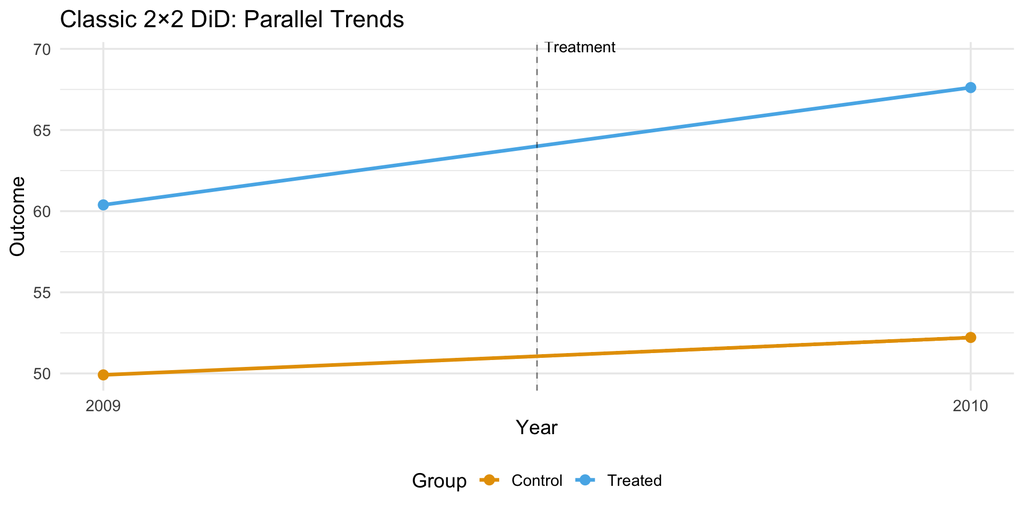

## Two-Way Fixed Effects (TWFE) Regression

**Why TWFE Works in 2×2 Designs**

- Only one treatment timing (everyone treated at once or never)
- Single before/after comparison
- Treatment effect homogeneity not required
- Clean identification of average treatment effect

# Part 2: When DiD Fails

## Common Pitfalls and How to Avoid Them

### ❌ What NOT to Do

- Using TWFE with staggered adoption
- Ignoring treatment effect heterogeneity
- Not checking pre-trends
- Wrong standard errors
- Including post-treatment as controls
- Testing multiple specs, reporting one

### ✓ Best Practices

- Use heterogeneity-robust methods
- Always visualize pre-trends
- Report multiple aggregations
- Cluster SEs correctly
- Conduct sensitivity analysis
- Pre-register when possible

**Warning Signs Your DiD May Be Invalid**

- Pre-treatment effects are significant and large
- Effects change dramatically with specification changes
- Bacon decomposition shows heavy negative weights
- TWFE and robust methods give very different answers

## The Problem: TWFE with Staggered Adoption

**When units are treated at different times, TWFE can give **severely biased** estimates**

When treatment effects vary across groups or over time, TWFE weights can be **negative**, causing severe bias

### Homogeneous Effects

Effect is same for everyone

- TWFE works fine
- Negative weights don’t matter
- Get correct average effect

### Heterogeneous Effects

Effects differ by group/time

- TWFE can be severely biased
- Negative weights cause problems
- **Can even reverse signs!**

**Common Sources of Heterogeneity**

- Effects grow/fade over time
- Different effect sizes by region
- Treatment intensity varies
- Anticipation effects differ

# Part 3: Modern Solutions

## Heterogeneity-Robust Methods

**Three leading approaches that handle staggered adoption correctly**

### 1. Callaway & Sant’Anna (2021)

- Estimates group-time ATT(g,t) using clean 2×2 comparisons
- **Pros:** Most flexible, doubly robust, multiple aggregations
- **Cons:** Can be less efficient
- **R Package:** `did`

### 2. Sun & Abraham (2021)

- Interaction-weighted estimator with cohort-specific indicators
- **Pros:** Easy to implement, works well for event studies
- **R Package:** `fixest::sunab()`

### 3. Borusyak, Jaravel & Spiess (2024)

- Imputation-based approach on not-yet-treated observations
- **Pros:** Most efficient under strong assumptions
- **R Package:** `did2s`

**When to Use Which Method?**

- **Default choice:** Callaway-Sant’Anna (most robust)
- **Event studies:** Sun-Abraham (easy in `fixest`)
- **Maximum efficiency:** Borusyak-Jaravel-Spiess (strong assumptions)

## Example 3: Callaway-Sant’Anna Implementation

```r
# Install if needed
install.packages("did")
```

```r
library(did)

set.seed(456)
data_staggered <- expand.grid(state = 1:50, year = 2010:2020)

data_staggered <- data_staggered %>%
  mutate(
    treat_year = case_when(
      state <= 20 ~ 2015,
      state <= 35 ~ 2018,
      TRUE ~ NA_real_
    ),
    time_to_treat = ifelse(!is.na(treat_year), year - treat_year, -1000)
  )

# True dynamic effects (growing over time)
data_staggered <- data_staggered %>%
  mutate(
    true_effect = case_when(
      time_to_treat < 0 ~ 0,
      time_to_treat == 0 ~ 3,
      time_to_treat == 1 ~ 8,
      time_to_treat == 2 ~ 12,
      time_to_treat >= 3 ~ 15,
      TRUE ~ 0
    ),
    outcome = 50 + 2*(year - 2010) + true_effect + rnorm(n(), 0, 5)
  )

# Prepare data for CS method
data_cs <- data_staggered %>%
  filter(!is.na(treat_year) | state > 35) %>%
  mutate(treat_year = ifelse(is.na(treat_year), 0, treat_year))

# Estimate group-time effects
cs_results <- att_gt(
  yname = "outcome",
  tname = "year",
  idname = "state",
  gname = "treat_year",
  data = data_cs,
  control_group = "notyettreated",
  est_method = "dr"
)
```

## Example 3: CS Results - Overall ATT

```r
# Overall ATT (simple average)
agg_simple <- aggte(cs_results, type = "simple")
summary(agg_simple)
```

```
Call:
aggte(MP = cs_results, type = "simple")

Reference: Callaway, Brantly and Pedro H.C. Sant'Anna.  "Difference-in-Differences with Multiple Time Periods." Journal of Econometrics, Vol. 225, No. 2, pp. 200-230, 2021. <https://doi.org/10.1016/j.jeconom.2020.12.001>, <https://arxiv.org/abs/1803.09015>

    ATT    Std. Error     [ 95%  Conf. Int.]
 9.7687          1.24     7.3384      12.199 *


---
Signif. codes: `*' confidence band does not cover 0

Control Group:  Not Yet Treated,  Anticipation Periods:  0
Estimation Method:  Doubly Robust
```

**Tip**

The overall ATT averages effects across all treated groups and time periods

## Example 3: CS Results - Dynamic Effects

```r
# Dynamic effects (event study)
agg_dynamic <- aggte(cs_results, type = "dynamic")
summary(agg_dynamic)
```

```
Call:
aggte(MP = cs_results, type = "dynamic")

Reference: Callaway, Brantly and Pedro H.C. Sant'Anna.  "Difference-in-Differences with Multiple Time Periods." Journal of Econometrics, Vol. 225, No. 2, pp. 200-230, 2021. <https://doi.org/10.1016/j.jeconom.2020.12.001>, <https://arxiv.org/abs/1803.09015>


Overall summary of ATT's based on event-study/dynamic aggregation:
     ATT    Std. Error     [ 95%  Conf. Int.]
 10.6951        1.2643     8.2171     13.1732 *


Dynamic Effects:
 Event time Estimate Std. Error [95% Simult.  Conf. Band]
         -7   2.5867     2.1536       -3.2873      8.4607
         -6   1.2821     2.1451       -4.5687      7.1328
         -5  -1.8347     2.1482       -7.6938      4.0245
         -4  -1.0752     1.7509       -5.8508      3.7004
         -3   0.7623     1.7879       -4.1141      5.6387
         -2  -0.5589     1.5596       -4.8127      3.6949
         -1   0.8852     1.6540       -3.6261      5.3966
          0   1.7016     1.4813       -2.3386      5.7419
          1   7.1334     1.5717        2.8465     11.4202 *
          2  13.0596     1.6318        8.6089     17.5104 *
          3  13.0956     2.2934        6.8404     19.3508 *
          4  16.1426     2.0264       10.6155     21.6697 *
          5  13.0379     2.2688        6.8497     19.2261 *
---
Signif. codes: `*' confidence band does not cover 0

Control Group:  Not Yet Treated,  Anticipation Periods:  0
Estimation Method:  Doubly Robust
```

## Example 3: CS Event Study Visualization

```r
# Plot event study
ggdid(agg_dynamic,
      xlab = "Time to Treatment",
      ylab = "ATT",
      title = "Callaway-Sant'Anna Event Study (Correct!)") +
  geom_hline(yintercept = 0, linetype = "dashed", color = "red") +
  theme_minimal(base_size = 14)
```

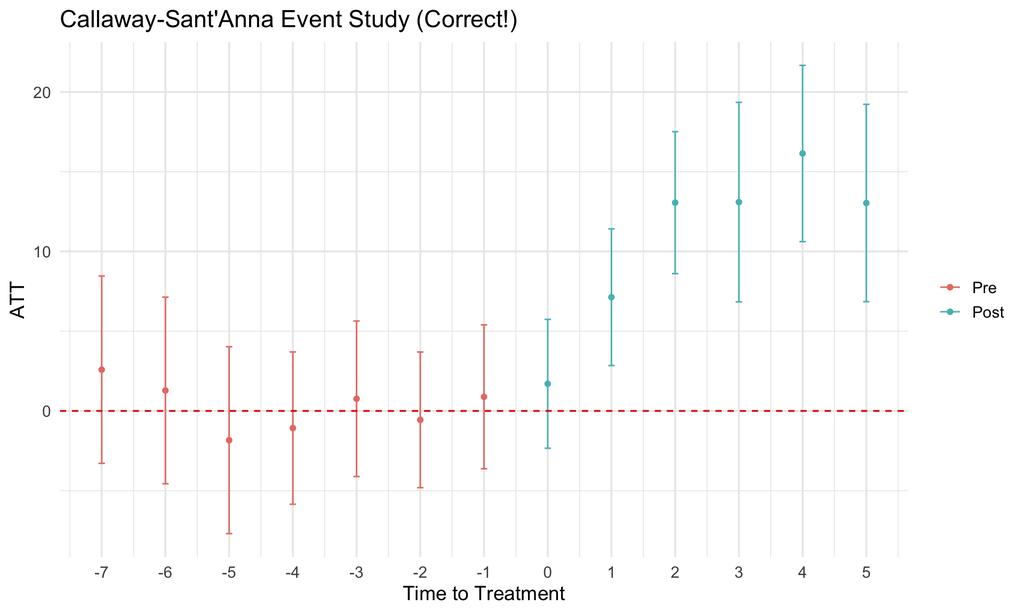

## Data Structure and Requirements

**Required Data Format: Panel Data**

### Required Variables

- **Unit ID:** Unique identifier for each unit (state, firm, individual)
- **Time variable:** Period indicator (year, quarter, month)
- **Outcome:** The dependent variable of interest
- **Treatment timing:** When each unit first receives treatment (NA for never-treated)

### Key Considerations

- **Treatment is absorbing:** Once treated, units stay treated (no switching off)
- **Never-treated units:** Coded with NA or 0 for `treat_year`
- **Pre-treatment periods:** Need sufficient periods before first treatment
- **Covariates:** Optional but can improve precision

## Diagnostic Testing: Pre-Trends

**Parallel Trends Cannot Be Proven, But Can Be Made More Plausible**

### 1. Visual Inspection

Plot outcome trends for treated vs control groups before treatment

### 2. Formal Pre-Trend Tests

Test if pre-treatment effects are jointly zero

⚠️ **Warning:** These tests often have **low power**

### 3. Placebo Tests

- Use fake treatment dates in pre-period
- Test on untreated units only
- Should find no effect if parallel trends holds

## Diagnostic Testing: Sensitivity Analysis

```r
# Sensitivity analysis with HonestDiD
# install.packages("HonestDiD")
library(HonestDiD)

# Create sensitivity analysis
# How large would trend violations need to be to overturn conclusions?
robust_ci <- createSensitivityResults(
  betahat = coef_vector,
  sigma = vcov_matrix,
  M = 0.5  # Bound on trend violations
)
```

**Tip**

Instead of treating parallel trends as a binary assumption, ask:

**“How large would trend violations need to be to overturn my conclusions?”**

## Standard Errors and Inference

**Standard errors are critical! Incorrect SEs can lead to invalid inference**

### Clustering Rules of Thumb

- **Default:** Cluster at the unit level (state, firm, individual)
- **Why?** Treatment typically assigned at unit level, creating within-unit correlation
- **Two-way clustering:** If treatment correlates across both units and time

```r
# With fixest
library(fixest)
model <- feols(outcome ~ treatment | unit + time,
               data = data,
               cluster = ~ unit)  # Cluster at unit level

# With did package (automatic clustering)
cs_results <- att_gt(...)

# Bootstrap standard errors (alternative)
cs_boot <- att_gt(..., boot = TRUE, nboot = 1000)
```

# Key Takeaways

## The DiD Revolution Changed Everything

1. **Traditional TWFE is often WRONG**
   - With staggered adoption and heterogeneous effects, TWFE can be severely biased
2. **Use heterogeneity-robust methods**
   - Callaway-Sant’Anna, Sun-Abraham, or Borusyak-Jaravel-Spiess are now best practice
3. **Parallel trends is CRITICAL**
   - Check pre-trends visually, conduct sensitivity analysis, be transparent
4. **Report heterogeneity**
   - Show dynamic effects, by-group effects, not just one number
5. **Standard errors matter**
   - Cluster at the treatment assignment level

**Default choice:**

Use Callaway-Sant’Anna

with the `did` package

## Additional Resources

### Key Papers

- **Goodman-Bacon (2021)** - “Difference-in-differences with variation in treatment timing”
- **Callaway & Sant’Anna (2021)** - “Difference-in-Differences with multiple time periods”
- **Sun & Abraham (2021)** - “Estimating dynamic treatment effects in event studies”
- **Roth et al. (2023)** - “What’s trending in difference-in-differences”

### Books & Online Resources

- **The Effect** (Huntington-Klein) - Free online textbook
- **Causal Inference: The Mixtape** (Cunningham) - Free online
- **LOST** (Library of Statistical Techniques) - Code examples

### Software Documentation

- `did` package: bcallaway11.github.io/did/
- `fixest`: lrberge.github.io/fixest/